# Importing and Scraping Data … and random tidying tools

## Setup

Welcome to another tutorial for this class, COMP/STAT 112: *Introduction to Data Science*! It will be similar to the others, including demo videos and files embedded in this document and practice problems with hints or solutions at the end. There are some new libraries, so be sure to install those first.

As most of our files do, we start this one with three R code chunks: 1. options, 2. libraries and settings, 3. data.

```r
knitr::opts_chunk$set(echo = TRUE,
                      message = FALSE,
                      warning = FALSE)
```

```r
library(tidyverse)     # for data cleaning and plotting
library(googlesheets4) # for reading googlesheet data
library(lubridate)     # for date manipulation
library(openintro)     # for the abbr2state() function
library(palmerpenguins)# for Palmer penguin data
library(maps)          # for map data
library(ggmap)         # for mapping points on maps
library(gplots)        # for col2hex() function
library(RColorBrewer)  # for color palettes
library(sf)            # for working with spatial data
library(leaflet)       # for highly customizable mapping
library(ggthemes)      # for more themes (including theme_map())
library(plotly)        # for the ggplotly() - basic interactivity
library(gganimate)     # for adding animation layers to ggplots
library(gifski)        # for creating the gif (don't need to load this library every time,but need it installed)
library(transformr)    # for "tweening" (gganimate)
library(shiny)         # for creating interactive apps
library(patchwork)     # for nicely combining ggplot2 graphs
library(gt)            # for creating nice tables
library(rvest)         # for scraping data
library(robotstxt)     # for checking if you can scrape data
gs4_deauth()           # To not have to authorize each time you knit.
theme_set(theme_minimal())
```

```r
# Lisa's garden data
garden_harvest <- read_sheet("https://docs.google.com/spreadsheets/d/1DekSazCzKqPS2jnGhKue7tLxRU3GVL1oxi-4bEM5IWw/edit?usp=sharing") %>%
  mutate(date = ymd(date))
```

## Learning Goals

After this tutorial, you should be able to do the following:

- Import data into R that is stored in a common file type (.csv, .txt, excel, etc) or in a Google spreadsheet.
- Find resources to read in data that is in a format other than one of the more common formats.
- Use `rvest()` functions to scrape data from a simple webpage and recognize when scraping the data will require more advanced tools.
- Create nice tables with the `gt` functions.
- Use `patchwork` to display related plots together nicely.

## Importing Data

In this section, we’ll learn some of the common ways we can import data into R. Many of these functions you have already used and others you may not ever need to use. So, this will be a pretty quick overview.

### Common Import functions

The table below lists some common import functions and when you would use them.

[output not shown]

After reading in new data, it is ALWAYS a good idea to do some quick checks of the data. Here are some things I always do:

1. Open the data in the spreadsheet-like viewer and take a look at it. Sort it by different variables by clicking on the arrows next to the variable name. Make sure there isn’t anything unexpected.
2. Do a quick summary of the data. The code below is one of the things I almost always do because it’s quick. For quantitative variables, it tells me some summary statistics and will let me know if there are missing values. For factors (they need to be factors, not just character variables - the `mutate()` changes them to factors), it shows you counts for the top categories and tells you if there are any missing values.

```r
garden_harvest %>%
  mutate(across(where(is.character), as.factor)) %>%
  summary()
```

```
##      vegetable                    variety         date
##  tomatoes :232   grape                : 37   Min.   :2020-06-06
##  lettuce  : 68   Romanesco            : 34   1st Qu.:2020-07-21
##  beans    : 38   pickling             : 32   Median :2020-08-09
##  zucchini : 34   Lettuce Mixture      : 28   Mean   :2020-08-08
##  cucumbers: 32   Farmer's Market Blend: 27   3rd Qu.:2020-08-26
##  peas     : 27   Bonny Best           : 26   Max.   :2020-10-03
##  (Other)  :254   (Other)              :501
##      weight         units
##  Min.   :   2.0   grams:685
##  1st Qu.:  86.0
##  Median : 252.0
##  Mean   : 501.8
##  3rd Qu.: 599.0
##  Max.   :7350.0
##
```

3. After that, I usually do some quick summaries (counts, sums, etc.) of some of the main variables I am interested in.

### Using the Import Dataset Wizard

When reading in data from a file I created, I will often use the Import Wizard to help me write the code. DO NOT use it to import the data as you will need the code to read in the data in order to knit your document. Watch the quick video below of how I use it.

[video not shown]

[Voicethread: Using the Import Dataset Wizard](https://voicethread.com/share/15717600/)

### Resources

- [R4DS](https://r4ds.had.co.nz/data-import.html)
- [readr documentation](https://readr.tidyverse.org/) and data import cheatsheet

### Your Turn!

#### Exercise 1

Read in the fake garden harvest data. Find the data [here](https://github.com/llendway/scraping_etc/blob/main/2020_harvest.csv) and click on the `Raw` button to get a direct link to the data.

#### Exercise 2

Read in this [data](https://www.kaggle.com/heeraldedhia/groceries-dataset) from the kaggle website. You will need to download the data first. Do some quick checks of the data to assure it has been read in appropriately.

## Scraping Data

This section COMING SOON!

## Creating nice tables

For this part, you should download the files that go with the demo video by Rich Iannone and follow along! I’ve added a few things that he didn’t cover in the video and made a couple small changes since a few of the functions have changed since he made the video.

### Demo video (it’s not me!)

[video not shown]

### Resources

- [Rich Iannone’s](https://www.youtube.com/watch?v=h1KAjSfSbmk) demo
- [Guidelines for Better Tables in R](https://themockup.blog/posts/2020-09-04-10-table-rules-in-r/) by Thomas Mock
- [gt documentation](https://gt.rstudio.com/reference/index.html) - a lot of detail but great place to go to see all the functions available

### Your turn!

#### Exercise 1

Write code to replicate the table shown below created from the `garden_harvest` data:

[figure not shown]

#### Exercise 2

Create a table using `gt` with data from your project.

## Combining graphs with `patchwork`

I am only going to show you a couple of my favorite parts of `patchwork`. I encourage you to look at more details in the resources I listed below.

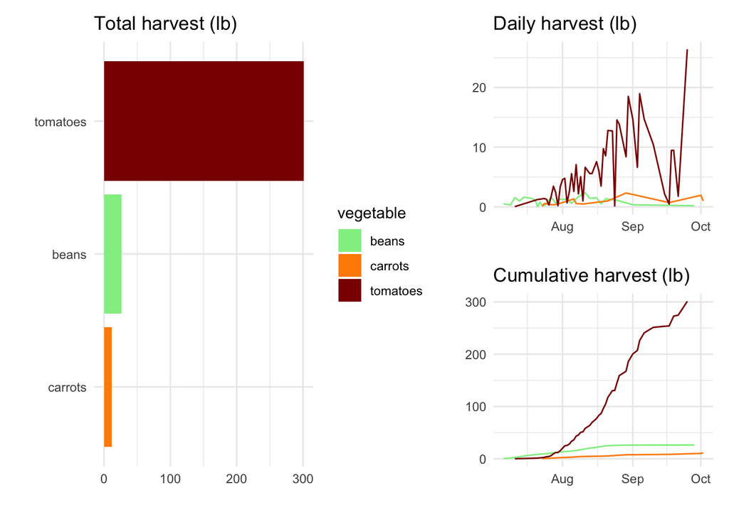

```r
g1 <- garden_harvest %>%
  filter(vegetable %in% c("tomatoes", "beans", "carrots")) %>%
  group_by(vegetable, date) %>%
  summarize(daily_harvest_lb = sum(weight)*0.00220462) %>%
  ggplot(aes(x = date,
             y = daily_harvest_lb,
             color = vegetable)) +
  geom_line() +
  scale_color_manual(values = c("beans" = "lightgreen",
                                "carrots" = "darkorange",
                                "tomatoes" = "darkred")) +
  labs(x = "",
       y = "",
       title = "Daily harvest (lb)") +
  theme(legend.position = "none")

g2 <- garden_harvest %>%
  filter(vegetable %in% c("tomatoes", "beans", "carrots")) %>%
  group_by(vegetable, date) %>%
  summarize(daily_harvest_lb = sum(weight)*0.00220462) %>%
  mutate(cum_harvest_lb = cumsum(daily_harvest_lb)) %>%
  ggplot(aes(x = date,
             y = cum_harvest_lb,
             color = vegetable)) +
  geom_line() +
  scale_color_manual(values = c("beans" = "lightgreen",
                                "carrots" = "darkorange",
                                "tomatoes" = "darkred")) +
  labs(x = "",
       y = "",
       title = "Cumulative harvest (lb)") +
  theme(legend.position = "none")

g3 <- garden_harvest %>%
  filter(vegetable %in% c("tomatoes", "beans", "carrots")) %>%
  group_by(vegetable) %>%
  summarize(total_harvest_lb = sum(weight)*0.00220462) %>%
  ggplot(aes(x = total_harvest_lb,
             y = fct_reorder(vegetable, total_harvest_lb, .desc = FALSE),
             fill = vegetable)) +
  geom_col() +
  scale_fill_manual(values = c("beans" = "lightgreen",
                                "carrots" = "darkorange",
                                "tomatoes" = "darkred")) +
  labs(x = "",
       y = "",
       title = "Total harvest (lb)")

g3 | (g1/g2) +
  plot_annotation(title = "Look at these cool plots")
```

There are many functions that help use shared legends, align plots, and more. So be sure to check out the resources below.

### Resources

- [GitHub page](https://github.com/thomasp85/patchwork): scroll to the bottom to see more detailed links in the “Learn more” section
- [Excellent example](https://www.littlemissdata.com/blog/patchwork) by Laura Ellis, aka @LittleMissData

### Your turn!

#### Exercise 1

Combine at least two garden graphs using the `patchwork` operators and functions. Check out the documentation for having shared legends.

#### Exercise 2

Combine at least two graphs using your project data.